# Predicting Forest Area – Cover Types

### Alexander Bartel

```python
import numpy as np
import pandas as pd
import matplotlib.pyplot as plt
from sklearn.tree import DecisionTreeClassifier
from sklearn.model_selection import train_test_split
from sklearn.metrics import confusion_matrix, classification_report
from sklearn.ensemble import RandomForestClassifier
from sklearn.preprocessing import OneHotEncoder
from sklearn.linear_model import LogisticRegression
```

## Part 1: Loading the Dataset; Preliminary Analysis

In this section I will load the forest_cover dataset and make a quick overview of the structure of the data.

```python
fc = pd.read_csv("forest_cover.txt", sep="\t")
fc.head(5)
```

|  | Elevation | Aspect | Slope | Horizontal_Distance_To_Hydrology | Vertical_Distance_To_Hydrology | Horizontal_Distance_To_Roadways | Hillshade_9am | Hillshade_Noon | Hillshade_3pm | Horizontal_Distance_To_Fire_Points | Wilderness_Area | Soil_Type | Cover_Type |
| --- | --- | --- | --- | --- | --- | --- | --- | --- | --- | --- | --- | --- | --- |
| 0 | 2596 | 51 | 3 | 258 | 0 | 510 | 221 | 232 | 148 | 6279 | Rawah | 29 | 5 |
| 1 | 2590 | 56 | 2 | 212 | -6 | 390 | 220 | 235 | 151 | 6225 | Rawah | 29 | 5 |
| 2 | 2804 | 139 | 9 | 268 | 65 | 3180 | 234 | 238 | 135 | 6121 | Rawah | 12 | 2 |
| 3 | 2785 | 155 | 18 | 242 | 118 | 3090 | 238 | 238 | 122 | 6211 | Rawah | 30 | 2 |
| 4 | 2595 | 45 | 2 | 153 | -1 | 391 | 220 | 234 | 150 | 6172 | Rawah | 29 | 5 |

Below, the size of the forest_cover dataset it printed. The shape tells us that there are 15,120 rows of data, or observations of patches of forest. The second number in the tuple returned by calling shape on the dataframe is the number of columns, or the number of features of the forest patches for which data was collected.

```python
print(fc.shape)
```

```
(15120, 13)
```

Now we will examine the distribution of the target variable, the type of forest cover for each patch of forest examined, and see that the 7 possible outcomes for this variable are equally represented in the dataset.

```python
fc.loc[:,'Cover_Type'].value_counts().sort_index()
```

```
1    2160
2    2160
3    2160
4    2160
5    2160
6    2160
7    2160
Name: Cover_Type, dtype: int64
```

Next I will create a list of named colors with each representing one type of forest coverage to use in visualizations later on.

```python
palette = ['orchid', 'lightcoral', 'orange', 'gold', 'lightgreen', 'deepskyblue', 'cornflowerblue']
```

## Part 2: Distribution of Cover Type by Wilderness Area

In this section we will specifically examine how the feature representing the type of wilderness area relates to the type of forest coverage.

```python
fc.loc[:,'Wilderness_Area'].value_counts().sort_index()
```

```
Cache la Poudre    4675
Comanche Peak      6349
Neota               499
Rawah              3597
Name: Wilderness_Area, dtype: int64
```

Next I will create a dataframe that will tell us how many observations from each wilderness area fall into each type of forest coverage.

```python
ct_by_wa = pd.crosstab(fc.loc[:,'Cover_Type'], fc.loc[:,'Wilderness_Area'])
ct_by_wa
```

| Wilderness_Area Cover_Type | Cache la Poudre | Comanche Peak | Neota | Rawah |
| --- | --- | --- | --- | --- |
| 1 | 0 | 917 | 181 | 1062 |
| 2 | 20 | 940 | 66 | 1134 |
| 3 | 1297 | 863 | 0 | 0 |
| 4 | 2160 | 0 | 0 | 0 |
| 5 | 0 | 1304 | 0 | 856 |
| 6 | 1198 | 962 | 0 | 0 |
| 7 | 0 | 1363 | 252 | 545 |

Now that we have this data we can use a stacked bar chart to visualize the distribution of coverage types by the different wilderness areas.

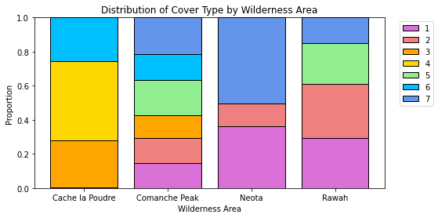

```python
wilderness_types = np.unique(fc.loc[:,'Wilderness_Area'])
ct_by_wa_props = ct_by_wa/np.sum(ct_by_wa, axis=0)
bb = np.cumsum(ct_by_wa_props)-ct_by_wa_props
plt.figure(figsize=[8,4])
for i in range(0,len(ct_by_wa_props)):
    plt.bar(x=wilderness_types, height=ct_by_wa_props.iloc[i, :], bottom=bb.iloc[i,:], edgecolor='black', color=palette[i], label=ct_by_wa.index[i])
plt.xlabel('Wilderness Area')
plt.ylabel('Proportion')
plt.title('Distribution of Cover Type by Wilderness Area')
plt.legend(bbox_to_anchor=[1.15,1])
plt.show()
```

## Part 3: Distribution of Cover Type by Soil Type

```python
ct_by_st = pd.crosstab(fc.loc[:,'Cover_Type'], fc.loc[:,'Soil_Type'])
ct_by_st
```

| Soil_Type Cover_Type | 1 | 2 | 3 | 4 | 5 | 6 | 8 | 9 | 10 | 11 | ... | 31 | 32 | 33 | 34 | 35 | 36 | 37 | 38 | 39 | 40 |
| --- | --- | --- | --- | --- | --- | --- | --- | --- | --- | --- | --- | --- | --- | --- | --- | --- | --- | --- | --- | --- | --- |
| 1 | 0 | 0 | 0 | 5 | 0 | 0 | 0 | 1 | 9 | 5 | ... | 114 | 230 | 184 | 0 | 3 | 0 | 0 | 80 | 79 | 49 |
| 2 | 0 | 3 | 12 | 20 | 0 | 7 | 1 | 9 | 81 | 67 | ... | 97 | 255 | 184 | 12 | 1 | 2 | 0 | 7 | 3 | 3 |
| 3 | 121 | 283 | 133 | 462 | 55 | 248 | 0 | 0 | 717 | 89 | ... | 0 | 5 | 0 | 0 | 0 | 0 | 0 | 0 | 0 | 0 |
| 4 | 139 | 94 | 799 | 133 | 39 | 244 | 0 | 0 | 170 | 24 | ... | 0 | 0 | 0 | 0 | 0 | 0 | 0 | 0 | 0 | 0 |
| 5 | 0 | 61 | 0 | 129 | 0 | 0 | 0 | 0 | 64 | 154 | ... | 87 | 100 | 115 | 4 | 0 | 0 | 0 | 0 | 0 | 0 |
| 6 | 95 | 182 | 18 | 87 | 71 | 151 | 0 | 0 | 1101 | 67 | ... | 7 | 30 | 66 | 2 | 0 | 0 | 0 | 0 | 0 | 0 |
| 7 | 0 | 0 | 0 | 7 | 0 | 0 | 0 | 0 | 0 | 0 | ... | 27 | 70 | 67 | 4 | 98 | 8 | 34 | 641 | 575 | 407 |

7 rows × 38 columns

Now this data can be visually represented in another stacked bar chart.

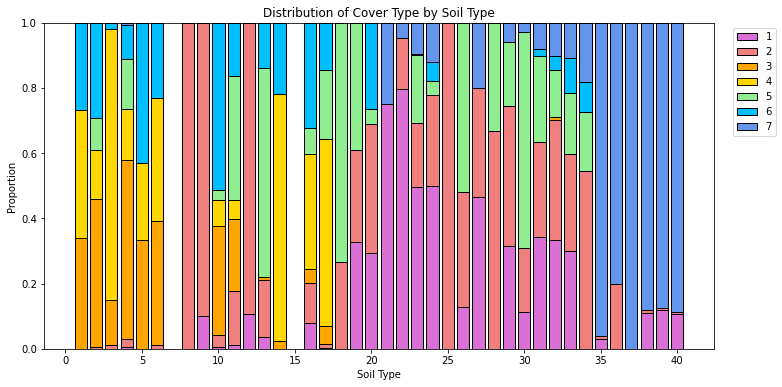

```python
soil_type_list = np.unique(fc.loc[:,'Soil_Type'])
ct_by_st_props = ct_by_st/np.sum(ct_by_st, axis=0)
bb = np.cumsum(ct_by_st_props)-ct_by_st_props
plt.figure(figsize=[12,6])
for i in range(0,len(ct_by_st_props)):
    plt.bar(x=soil_type_list, height=ct_by_st_props.iloc[i, :], bottom=bb.iloc[i,:], edgecolor='black', color=palette[i], label=ct_by_st.index[i])
plt.xlabel('Soil Type')
plt.ylabel('Proportion')
plt.title('Distribution of Cover Type by Soil Type')
plt.legend(bbox_to_anchor=[1.1,1])
plt.show()
```

## Part 4: Distribution of Elevation by Cover Type

In this section we will examine the distribution of different forest cover types by elevation. We will start by determining the average elevation of the samples with each of the seven cover types.

```python
fc.loc[:,['Elevation', 'Cover_Type']].groupby('Cover_Type').mean()
```

| Cover_Type | Elevation |
| --- | --- |
| 1 | 3128.025926 |
| 2 | 2922.540278 |
| 3 | 2398.423148 |
| 4 | 2223.420370 |
| 5 | 2786.801389 |
| 6 | 2423.276852 |
| 7 | 3362.769907 |

To help visualize these relationships, I will display this data using histograms to show the distribution of different elevations for each cover type.

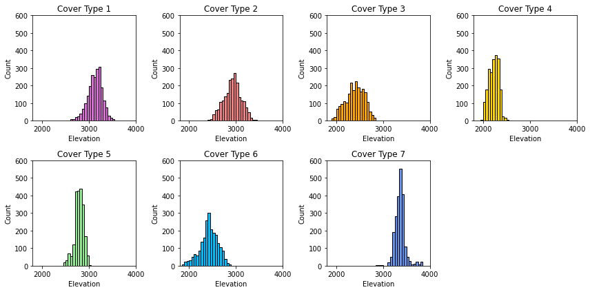

```python
plt.figure(figsize=[12,6])
for i in range(1, max(fc.loc[:,'Cover_Type'])+1):
    plt.subplot(2,4,i)
    plt.hist(fc.loc[fc.Cover_Type==i,'Elevation'], bins=np.arange(1800, 4050, 50), color=palette[i-1], edgecolor='black')
    plt.title(f'Cover Type {i}')
    plt.xlim([1800,4000])
    plt.ylim([0,600])
    plt.xlabel("Elevation")
    plt.ylabel("Count")
plt.tight_layout()
plt.show()
```

## Part 5: Creating Training, Validation, and Test Sets

In this section we will separate our data into training, validation, and testing sets. Our target variable is Cover_Type, and the rest of the columns will be features. Of the features, Wilderness_Area and Soil_Type are categorical variables while the rest are numerical, and we will separate the target variable, the categorical variables, and the numerical variables.

```python
X_num = fc.iloc[:, :10].values
X_cat = fc.iloc[:, 10:12].values
y = fc.iloc[:, 12].values
print(f'{"Numerical Feature Array Shape: ":<33}{X_num.shape}')
print(f'{"Categorical Feature Array Shape: ":<33}{X_cat.shape}')
print(f'{"Label Array Shape: ":<33}{y.shape}')
```

```
Numerical Feature Array Shape:   (15120, 10)
Categorical Feature Array Shape: (15120, 2)
Label Array Shape:               (15120,)
```

Now we will encode the categorical variables using one-hot encoding.

```python
encoder = OneHotEncoder(sparse=False)
encoder.fit(X_cat)
X_enc = encoder.transform(X_cat)
print("Encoded Feature Array Shape: ", X_enc.shape)
```

```
Encoded Feature Array Shape:  (15120, 42)
```

Now we will combine the numerical features with the encoded categorical features.

```python
X = np.hstack((X_num, X_enc))
print("Feature Array Shape: ", X.shape)
```

```
Feature Array Shape:  (15120, 52)
```

We will now split the data into training, validation, and test sets, with the training set being made up of 70% of the data, and the validation and test sets each being made up of 15% of the data.

```python
X_train, X_hold, y_train, y_hold = train_test_split(X, y, test_size=0.3, random_state=1, stratify=y)
X_valid, X_test, y_valid, y_test = train_test_split(X_hold, y_hold, test_size=0.5, random_state=1, stratify=y_hold)
print(f'{"Training Features Shape: ":<27}{X_train.shape}')
print(f'{"Validation Features Shape: ":<27}{X_valid.shape}')
print(f'{"Test Features Shape: ":<27}{X_test.shape}')
```

```
Training Features Shape:   (10584, 52)
Validation Features Shape: (2268, 52)
Test Features Shape:       (2268, 52)
```

## Part 6: Logistic Regression Model

In this part, I will use a logistic regression model to predict cover types based on the features in the dataset.

```python
lr_mod = LogisticRegression(solver='lbfgs', max_iter=1000, multi_class='multinomial', penalty='none')
lr_mod.fit(X_train, y_train)
print(f'{"Training Accuracy: ":<21}{round(lr_mod.score(X_train, y_train),4)}')
print(f'{"Validation Accuracy: ":<21}{round(lr_mod.score(X_valid, y_valid),4)}')
```

```
Training Accuracy:   0.6063
Validation Accuracy: 0.6111
```

## Part 7: Decision Tree Models

In this part, I will use a decision tree model to predict cover types based on the features in the dataset.

```python
dt_train_acc = []
dt_valid_acc = []
depth_range = range(2,31)
for d in depth_range:
    np.random.seed(1)
    temp_tree = DecisionTreeClassifier(max_depth=d)
    temp_tree.fit(X_train, y_train)
    dt_train_acc.append(temp_tree.score(X_train, y_train))
    dt_valid_acc.append(temp_tree.score(X_valid, y_valid))
dt_idx = np.argmax(dt_valid_acc)
dt_opt_depth = depth_range[dt_idx]
print(f'{"Optimal Value for max_depth: ":<33}{depth_range[dt_idx]}')
print(f'{"Training Accuracy for Optimal Model: ":<33}{round(dt_train_acc[dt_idx], 4)}')
print(f'{"Validation Accuracy for Optimal Model: ":<33}{round(dt_valid_acc[dt_idx], 4)}')
```

```
Optimal Value for max_depth:     18
Training Accuracy for Optimal Model: 0.9804
Validation Accuracy for Optimal Model: 0.772
```

Now, I will plot the training and validation accuracy curves for the decision tree model as a function of max_depth.

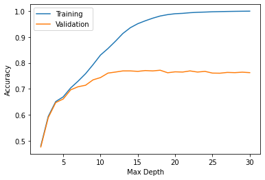

```python
plt.figure(figsize=[6,4])
plt.plot(depth_range, dt_train_acc, label='Training')
plt.plot(depth_range, dt_valid_acc, label='Validation')
plt.xlabel("Max Depth")
plt.ylabel("Accuracy")
plt.legend()
plt.show()
```

## Part 8: Random Forest Models

Now I will use a random forest model to predict cover type based on the features in the data. I will select the optimal value for max_depth by comparing the model's performance on the validation set with this parameter set to a range of values.

```python
rf_train_acc = []
rf_valid_acc = []
for d in depth_range:
    np.random.seed(1)
    temp_forest = RandomForestClassifier(max_depth=d, n_estimators=100)
    temp_forest.fit(X_train, y_train)
    rf_train_acc.append(temp_forest.score(X_train, y_train))
    rf_valid_acc.append(temp_forest.score(X_valid, y_valid))
rf_idx = np.argmax(rf_valid_acc)
rf_opt_depth = depth_range[rf_idx]
print(f'{"Optimal Value for max_depth: ":<33}{depth_range[rf_idx]}')
print(f'{"Training Accuracy for Optimal Model: ":<33}{round(rf_train_acc[rf_idx], 4)}')
print(f'{"Validation Accuracy for Optimal Model: ":<33}{round(rf_valid_acc[rf_idx], 4)}')
```

```
Optimal Value for max_depth:     28
Training Accuracy for Optimal Model: 1.0
Validation Accuracy for Optimal Model: 0.8677
```

Now, I will plot the training and validation accuracy curves for the random forest model as a function of max_depth.

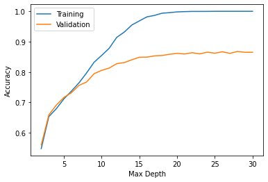

```python
plt.figure(figsize=[6,4])
plt.plot(depth_range, rf_train_acc, label='Training')
plt.plot(depth_range, rf_valid_acc, label='Validation')
plt.xlabel("Max Depth")
plt.ylabel("Accuracy")
plt.legend()
plt.show()
```

## Part 9: Create and Evaluate Final Model

The final model that I will select is a random forest model, given that it had the highest validation accuracy of the three at 0.8677, compared to a maximum of 0.772 for the optimal decision tree model, and 0.6111 for the logistic regression model. Of the different options for hyperparameters for the random forest model, I determined that the value for max_depth that had the highest validation accuracy was 28, so that is the value that will be used in the final model. For the n_estimators hyperparameter I will continue to use 100.

```python
np.random.seed(1)
final_model = RandomForestClassifier(max_depth=28, n_estimators=100)
final_model.fit(X_train, y_train)
print(f'{"Training Accuracy for Final Model: ":<31}{round(final_model.score(X_train, y_train), 4)}')
print(f'{"Validation Accuracy for Final Model: ":<31}{round(final_model.score(X_valid, y_valid), 4)}')
print(f'{"Testing Accuracy for Final Model: ":<31}{round(final_model.score(X_test, y_test), 4)}')
```

```
Training Accuracy for Final Model: 1.0
Validation Accuracy for Final Model: 0.8677
Testing Accuracy for Final Model: 0.8593
```

Now that the final model has been created, I will display a confusion matrix that provides details on how the model performed on the test set.

```python
test_pred = final_model.predict(X_test)
final_model_matrix = pd.DataFrame(confusion_matrix(y_test, test_pred), index=range(1,8), columns=range(1,8))
final_model_matrix
```

|  | 1 | 2 | 3 | 4 | 5 | 6 | 7 |
| --- | --- | --- | --- | --- | --- | --- | --- |
| 1 | 236 | 63 | 2 | 0 | 5 | 0 | 18 |
| 2 | 53 | 239 | 6 | 0 | 13 | 10 | 3 |
| 3 | 0 | 2 | 262 | 18 | 2 | 40 | 0 |
| 4 | 0 | 0 | 6 | 313 | 0 | 5 | 0 |
| 5 | 0 | 11 | 4 | 0 | 305 | 4 | 0 |
| 6 | 0 | 0 | 33 | 11 | 1 | 279 | 0 |
| 7 | 8 | 1 | 0 | 0 | 0 | 0 | 315 |

Now I will create a classification report with precision and recall information for each target label based on the same data.

```python
print(classification_report(y_test, test_pred))
```

```
              precision    recall  f1-score   support

           1       0.79      0.73      0.76       324
           2       0.76      0.74      0.75       324
           3       0.84      0.81      0.82       324
           4       0.92      0.97      0.94       324
           5       0.94      0.94      0.94       324
           6       0.83      0.86      0.84       324
           7       0.94      0.97      0.95       324

    accuracy                           0.86      2268
   macro avg       0.86      0.86      0.86      2268
weighted avg       0.86      0.86      0.86      2268
```